# 数据挖掘作业1——海藻数据分析

张霖

## 1. 实验环境配置

Windows 10

R 3.2.4

RStudio 0.99

## 2. R语言内配置

```r
install.packages('car','lattice','DMwR')
```

## 3. 实验过程

首先导入需要的程序包。

```r
library(car)
library(lattice)
library(DMwR)
```

### 3.1 读取数据

```r
algae = read.table('Analysis.txt',
col.names=c('season','size','speed','mxPH','mnO2','Cl','NO3','NH4','oPO4','PO4','Chla',
    'a1','a2','a3','a4','a5','a6','a7'),
na.string=c('XXXXXXX'))
```

代码如上所示。使用read.table函数将文本文档中的数据读取为R语言的data.frame类型。三个参数分别代表文件路径、列名以及缺失值设定。

### 3.2 数据摘要

```r
summary(algae)
```

```
##     season       size       speed         mxPH            mnO2
##  autumn:40   large :45   high  :84   Min.   :5.600   Min.   : 1.500
##  spring:53   medium:84   low   :33   1st Qu.:7.700   1st Qu.: 7.725
##  summer:45   small :71   medium:83   Median :8.060   Median : 9.800
##  winter:62                           Mean   :8.012   Mean   : 9.118
##                                      3rd Qu.:8.400   3rd Qu.:10.800
##                                      Max.   :9.700   Max.   :13.400
##                                      NA's   :1       NA's   :2
##        Cl               NO3              NH4                oPO4
##  Min.   :  0.222   Min.   : 0.050   Min.   :    5.00   Min.   :  1.00
##  1st Qu.: 10.981   1st Qu.: 1.296   1st Qu.:   38.33   1st Qu.: 15.70
##  Median : 32.730   Median : 2.675   Median :  103.17   Median : 40.15
##  Mean   : 43.636   Mean   : 3.282   Mean   :  501.30   Mean   : 73.59
##  3rd Qu.: 57.824   3rd Qu.: 4.446   3rd Qu.:  226.95   3rd Qu.: 99.33
##  Max.   :391.500   Max.   :45.650   Max.   :24064.00   Max.   :564.60
##  NA's   :10        NA's   :2        NA's   :2          NA's   :2
##       PO4              Chla               a1              a2
##  Min.   :  1.00   Min.   :  0.200   Min.   : 0.00   Min.   : 0.000
##  1st Qu.: 41.38   1st Qu.:  2.000   1st Qu.: 1.50   1st Qu.: 0.000
##  Median :103.29   Median :  5.475   Median : 6.95   Median : 3.000
##  Mean   :137.88   Mean   : 13.971   Mean   :16.92   Mean   : 7.458
##  3rd Qu.:213.75   3rd Qu.: 18.308   3rd Qu.:24.80   3rd Qu.:11.375
##  Max.   :771.60   Max.   :110.456   Max.   :89.80   Max.   :72.600
##  NA's   :2        NA's   :12
##        a3               a4               a5               a6
##  Min.   : 0.000   Min.   : 0.000   Min.   : 0.000   Min.   : 0.000
##  1st Qu.: 0.000   1st Qu.: 0.000   1st Qu.: 0.000   1st Qu.: 0.000
##  Median : 1.550   Median : 0.000   Median : 1.900   Median : 0.000
##  Mean   : 4.309   Mean   : 1.992   Mean   : 5.064   Mean   : 5.964
##  3rd Qu.: 4.925   3rd Qu.: 2.400   3rd Qu.: 7.500   3rd Qu.: 6.925
##  Max.   :42.800   Max.   :44.600   Max.   :44.400   Max.   :77.600
##
##        a7
##  Min.   : 0.000
##  1st Qu.: 0.000
##  Median : 1.000
##  Mean   : 2.495
##  3rd Qu.: 2.400
##  Max.   :31.600
##
```

### 3.3 数据可视化

这里以mxPH为例对数据可视化结果进行解释和分析。

#### 3.3.1 绘制直方图以及Q-Q图

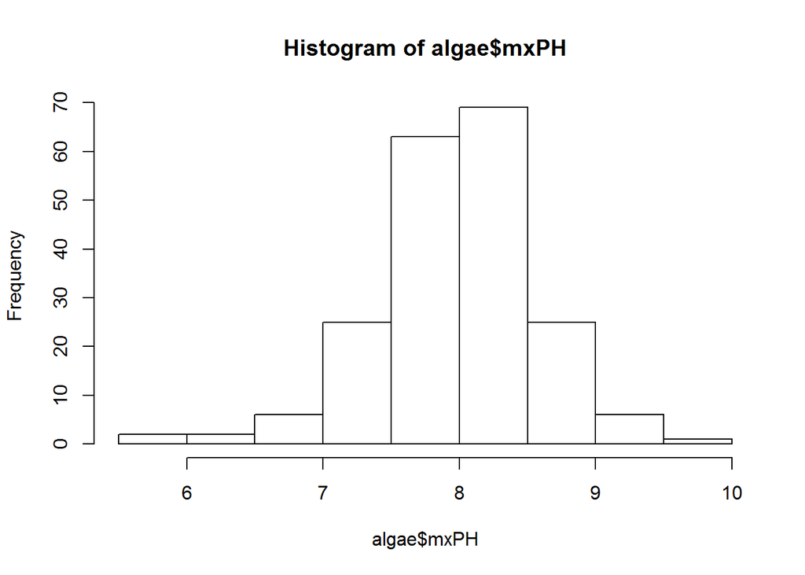

```r
#绘制直方图
hist(algae$mxPH)
```

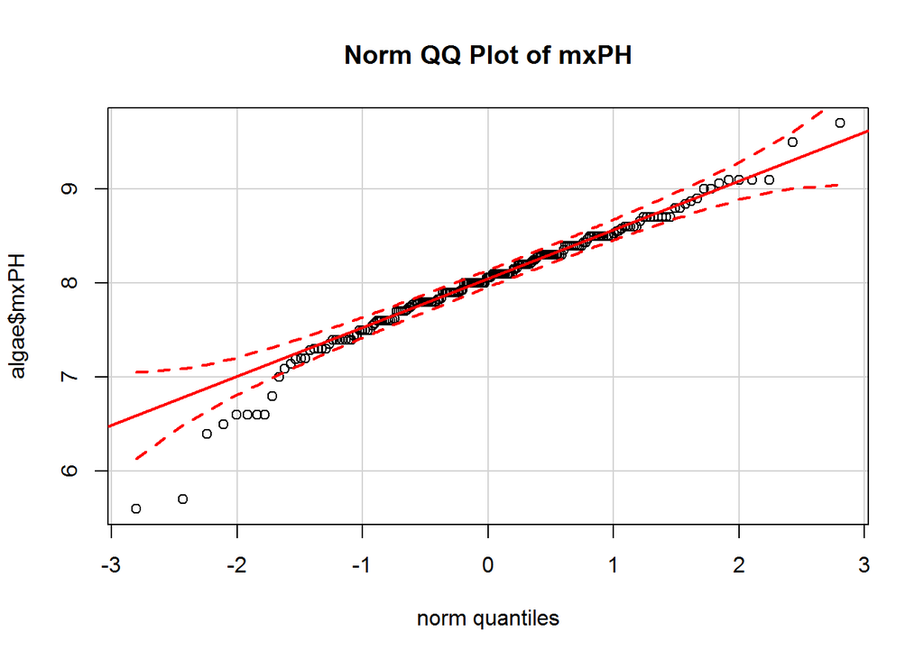

```r
#绘制QQ图
qqPlot(algae$mxPH,main='Norm QQ Plot of mxPH')
```

绘制直方图和Q-Q图的代码如上图所示。Q-Q图用的是分布的分位数来做检验。如果数据为正态分布，则在Q-Q正态分布图中，数据点应基本在图中对角线上。

Q-Q图中，红色实线表示Q-Q线，红色虚线表示置信度95%的置信区间。观察直方图和Q-Q图，可以看出数据大体符合高斯分布。

观察其他属性的结果，mxPH2基本符合高斯分布，而其他属性不符合高斯分布。

#### 3.3.2 绘制盒图

盒图也叫N-S图，有助于我们判断数据集的数据离散度和识别离群点。

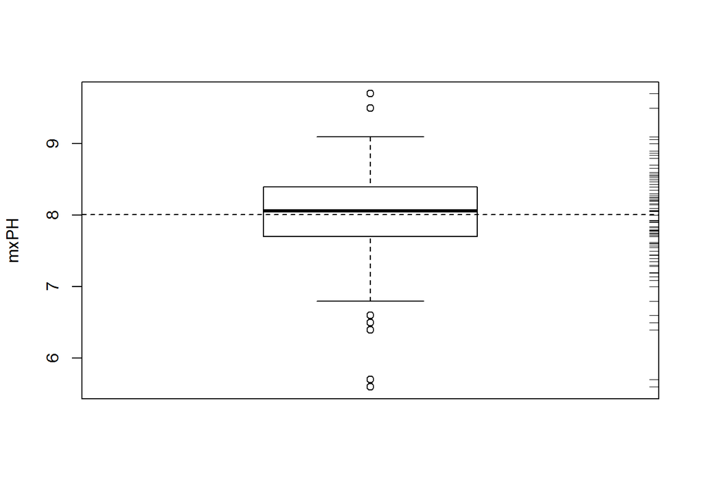

```r
boxplot(algae$mxPH,ylab='mxPH')
rug(algae$mxPH,side=4)
abline(h=mean(algae$mxPH,na.rm=T),lty=2)
```

### 3.3.3 绘制条件盒图

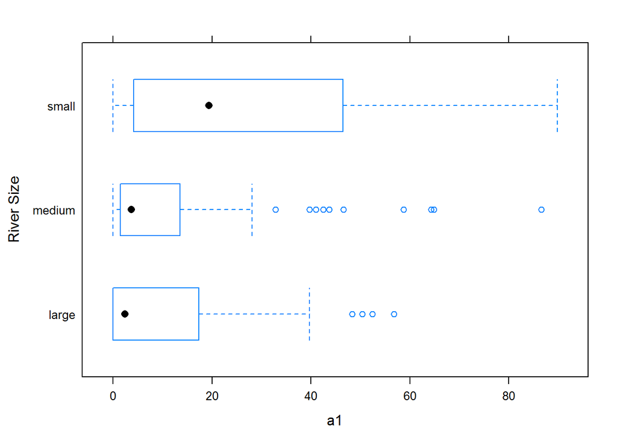

```r
bwplot(size~a1,data=algae,ylab='River Size',xlab='a1')
```

上图是a1海藻的条件盒图。可见，在规模较小的河流中，海藻a1的频率最高。

## 3.4 缺失数据处理

### 剔除缺失值

```r
#剔除缺失数据
omitdata = na.omit(algae)
write.table(omitdata,'OmitedData.txt',
    col.names = F,row.names = F, quote = F)
```

### 使用高频数据替换

```r
#使用高频数据替换
preprocess2 = algae[-manyNAs(algae),]
preprocess2 = centralImputation(preprocess2)
write.table(preprocess2,'CentralImputationData.txt',
col.names = F,row.names = F, quote = F)
```

### 通过变量相关性填补缺失值

```r
#通过变量相关性填补缺失值
symnum(cor(algae[,4:18],use='complete.obs'))
```

```
##      mP mO Cl NO NH o P Ch a1 a2 a3 a4 a5 a6 a7
## mxPH 1
## mnO2    1
## Cl         1
## NO3           1
## NH4           ,  1
## oPO4    .  .        1
## PO4     .  .        * 1
## Chla .                  1
## a1         .        . .    1
## a2   .                  .     1
## a3                               1
## a4      .           . .             1
## a5                                     1
## a6            .  .                     .  1
## a7                                           1
## attr(,"legend")
## [1] 0 ' ' 0.3 '.' 0.6 ',' 0.8 '+' 0.9 '*' 0.95 'B' 1
```

```r
lm(formula=PO4~oPO4, data=algae)
```

```
##
## Call:
## lm(formula = PO4 ~ oPO4, data = algae)
##
## Coefficients:
## (Intercept)         oPO4
##      42.897        1.293
```

```r
preprocess3 = algae[-manyNAs(algae),]
fillPO4 <- function(oP){
    if(is.na(oP))
        return(NA)
    else return (42.897 + 1.293 * oP)
}
preprocess3[is.na(preprocess3$PO4),'PO4'] <- sapply(preprocess3[is.na(preprocess3$PO4),'oPO4'],fillPO4)
write.table(preprocess3,'linearDefaultData.txt',
col.names = F,row.names = F, quote = F)
```

### 通过数据对象之间的相似型来填补缺失值

```r
#通过数据对象之间的相似型来填补缺失值
preprocess4 = knnImputation(algae,k=10)
write.table(preprocess4,'knnImputationData.txt',
col.names = F,row.names = F, quote = F)
```

## 4. 其他代码及结果

### 4.1 直方图及盒图

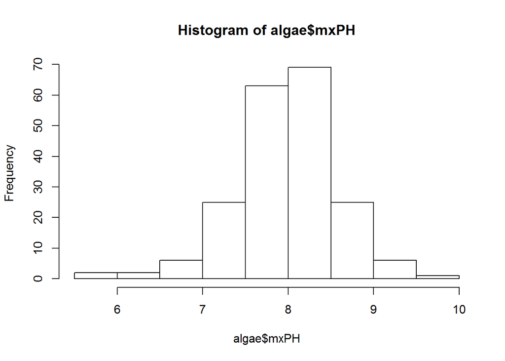

```r
hist(algae$mxPH)
```

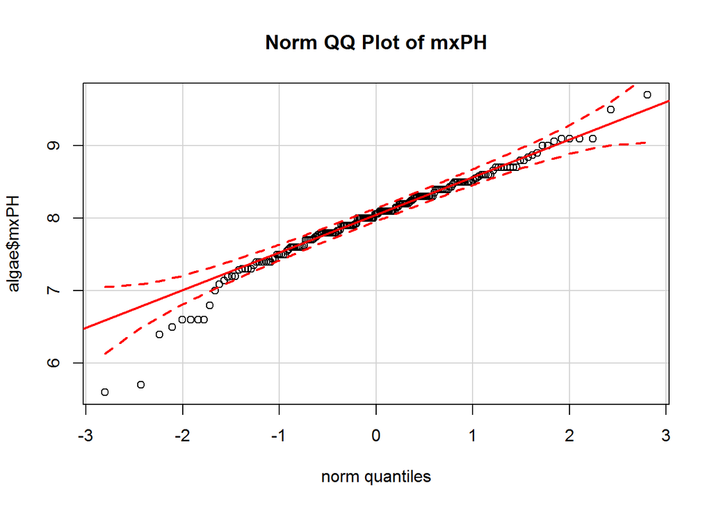

```r
qqPlot(algae$mxPH,main='Norm QQ Plot of mxPH')
```

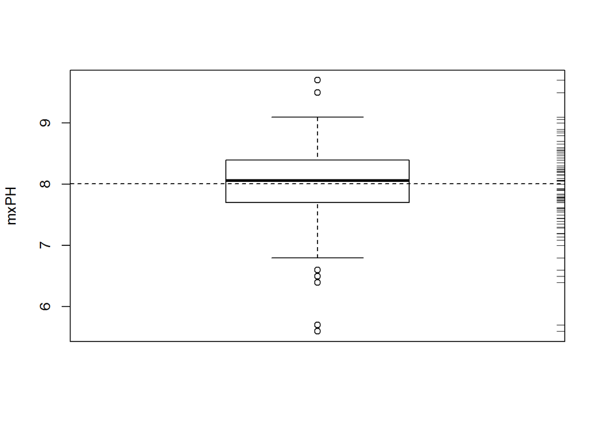

```r
boxplot(algae$mxPH,ylab='mxPH')
rug(algae$mxPH,side=4)
abline(h=mean(algae$mxPH,na.rm=T),lty=2)
```

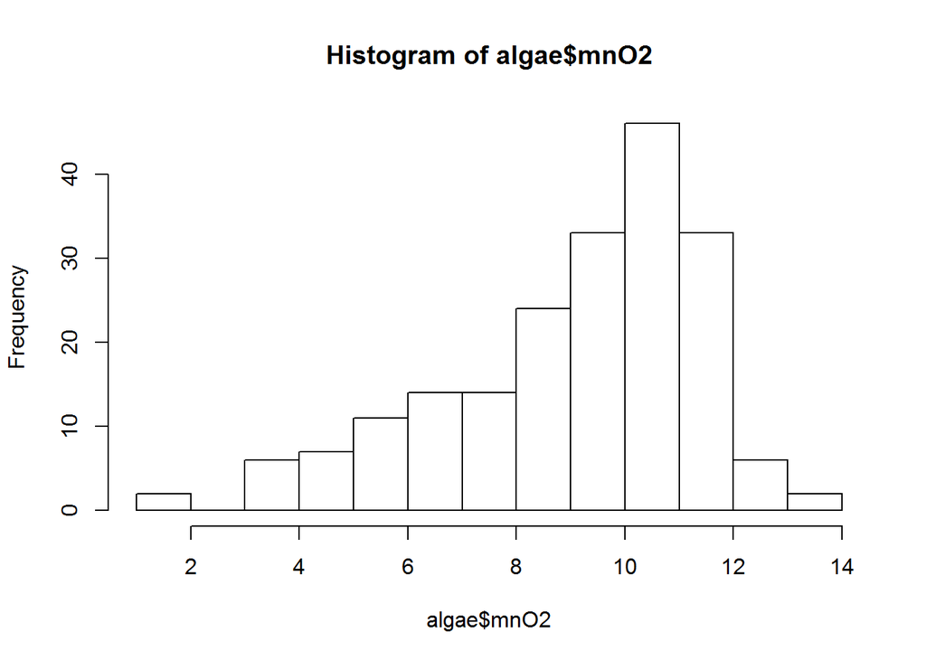

```r
hist(algae$mnO2)
```

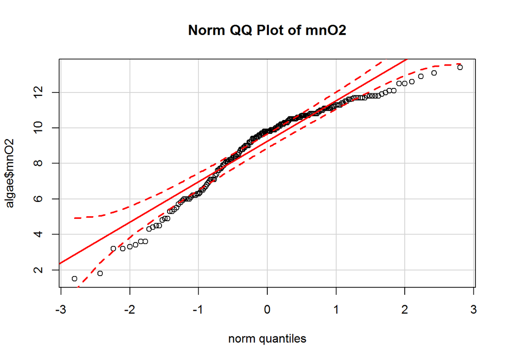

```r
qqPlot(algae$mnO2,main='Norm QQ Plot of mnO2')
```

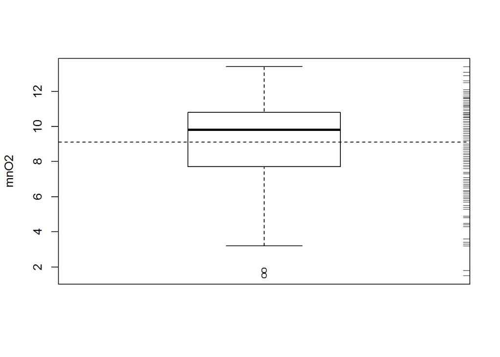

```r
boxplot(algae$mnO2,ylab='mnO2')
rug(algae$mnO2,side=4)
abline(h=mean(algae$mnO2,na.rm=T),lty=2)
```

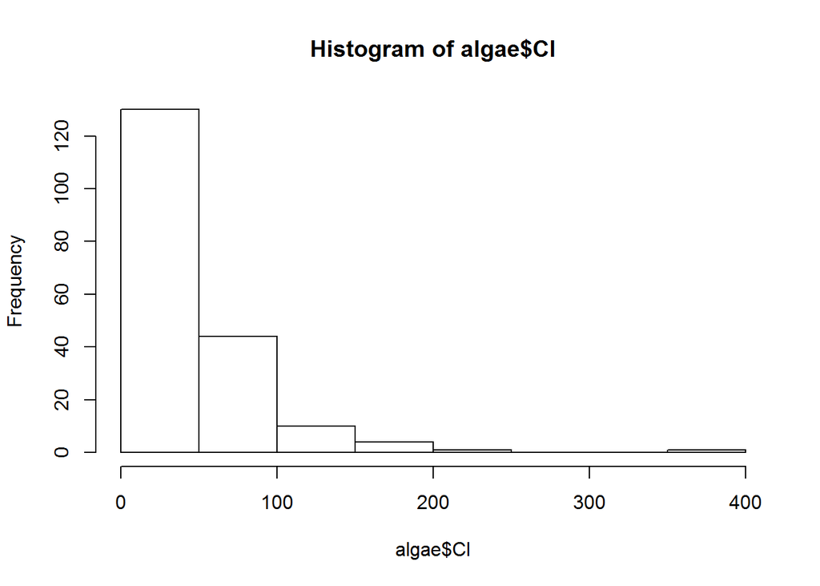

```r
hist(algae$Cl)
```

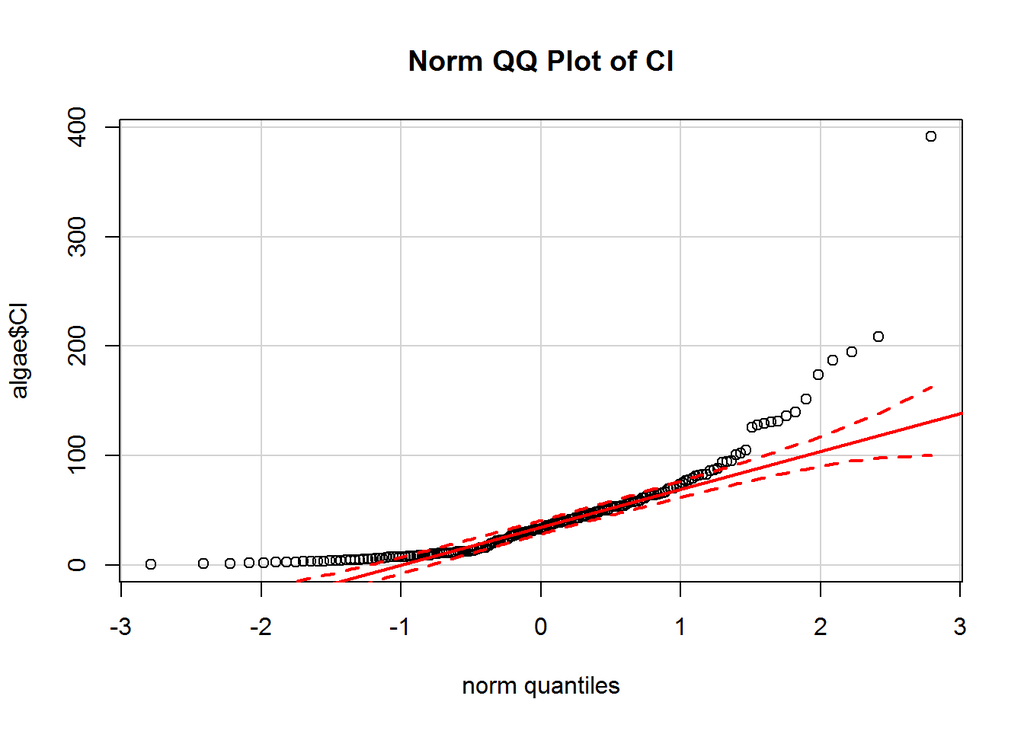

```r
qqPlot(algae$Cl,main='Norm QQ Plot of Cl')
```

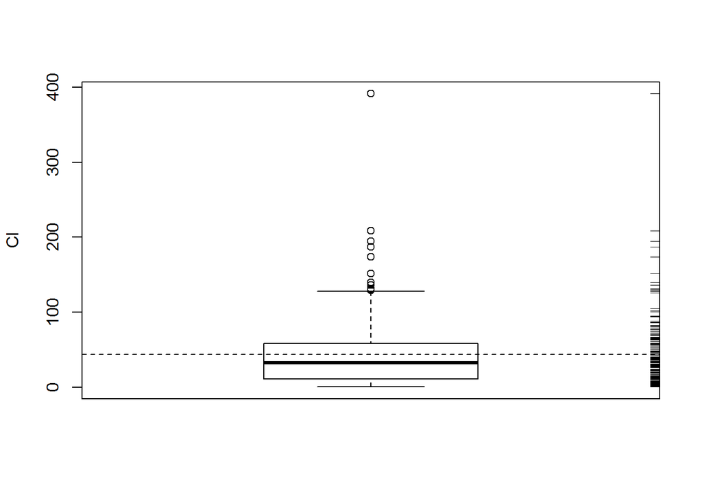

```r
boxplot(algae$Cl,ylab='Cl')
rug(algae$Cl,side=4)
abline(h=mean(algae$Cl,na.rm=T),lty=2)
```

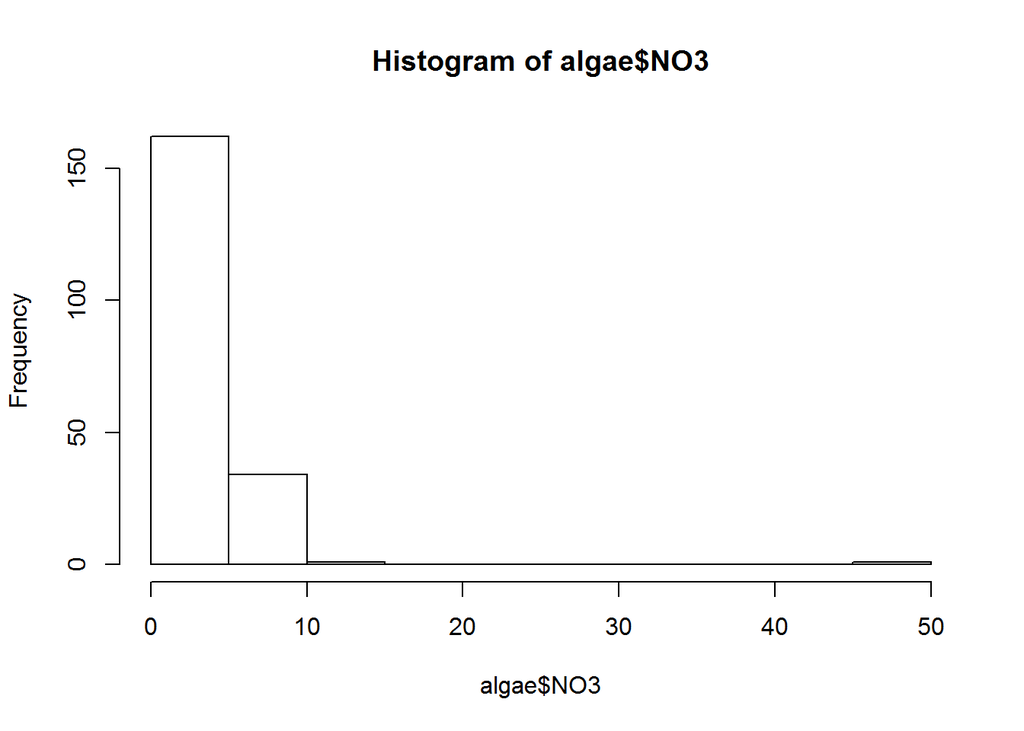

```r
hist(algae$NO3)
```

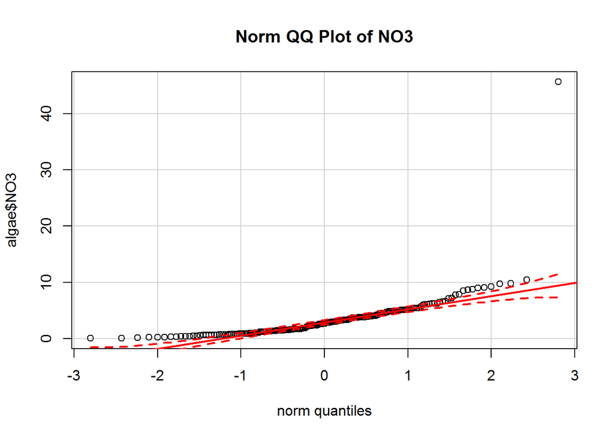

```r
qqPlot(algae$NO3,main='Norm QQ Plot of NO3')
```

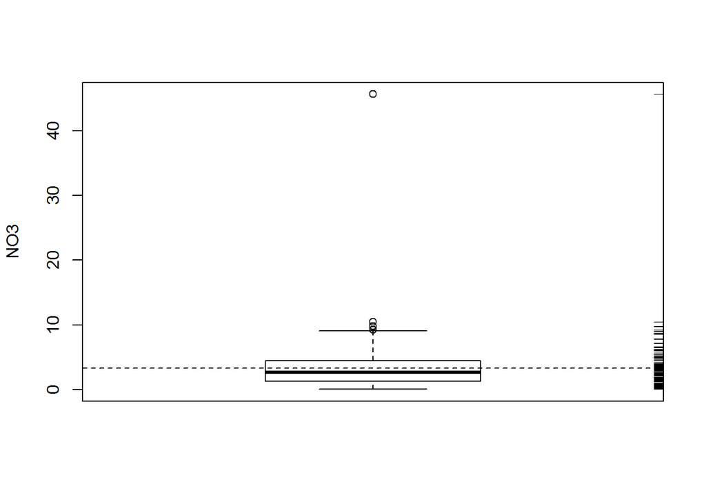

```r
boxplot(algae$NO3,ylab='NO3')
rug(algae$NO3,side=4)
abline(h=mean(algae$NO3,na.rm=T),lty=2)
```

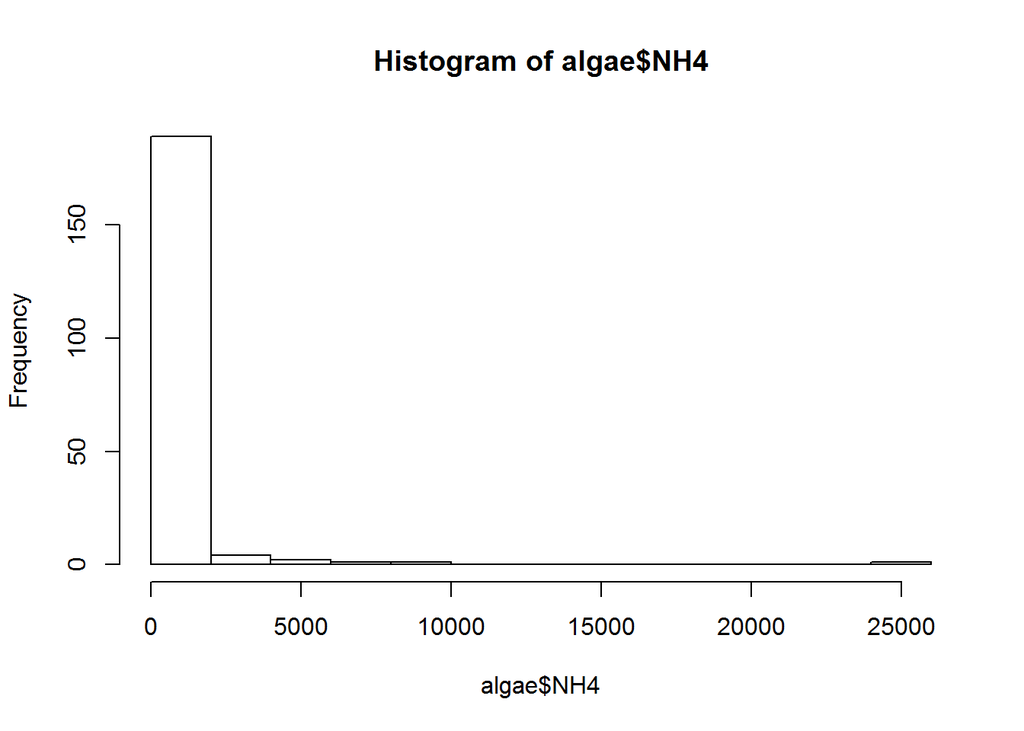

```r
hist(algae$NH4)
```

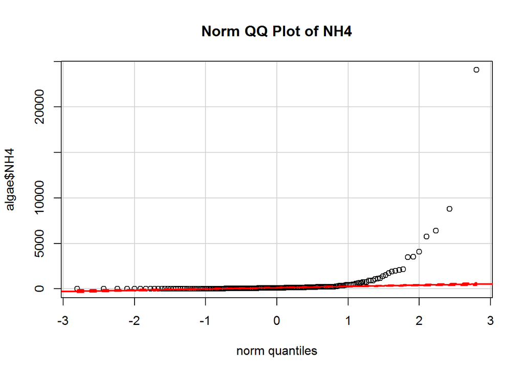

```r
qqPlot(algae$NH4,main='Norm QQ Plot of NH4')
```

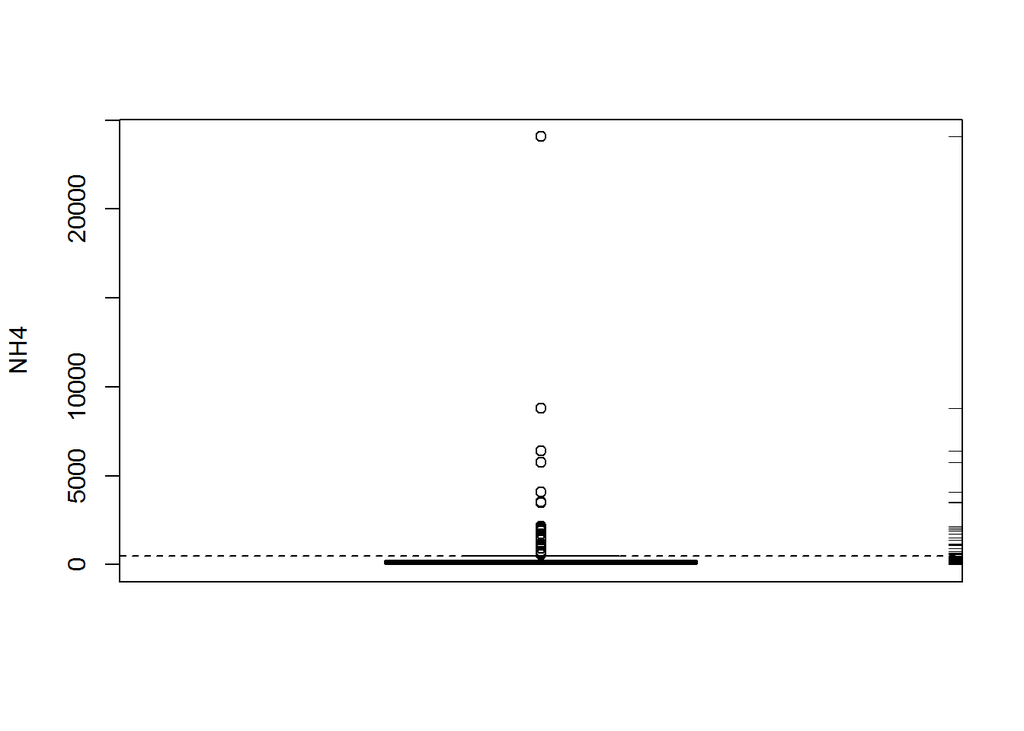

```r
boxplot(algae$NH4,ylab='NH4')
rug(algae$NH4,side=4)
abline(h=mean(algae$NH4,na.rm=T),lty=2)
```

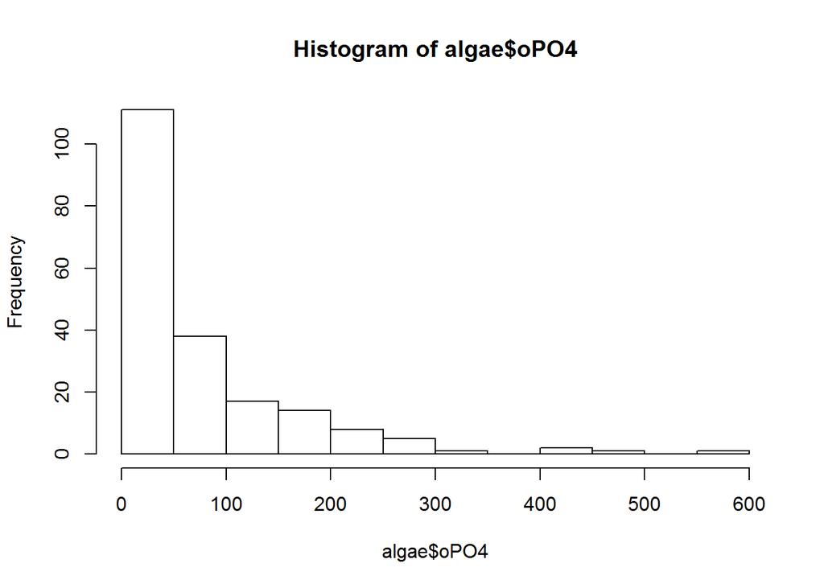

```r
hist(algae$oPO4)
```

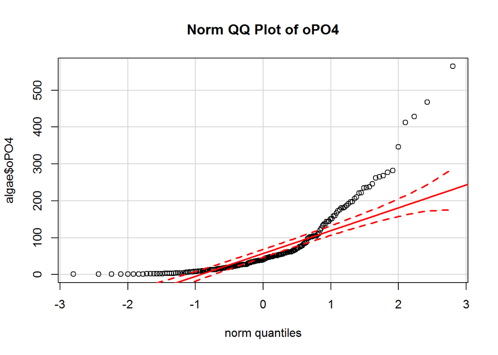

```r
qqPlot(algae$oPO4,main='Norm QQ Plot of oPO4')
```

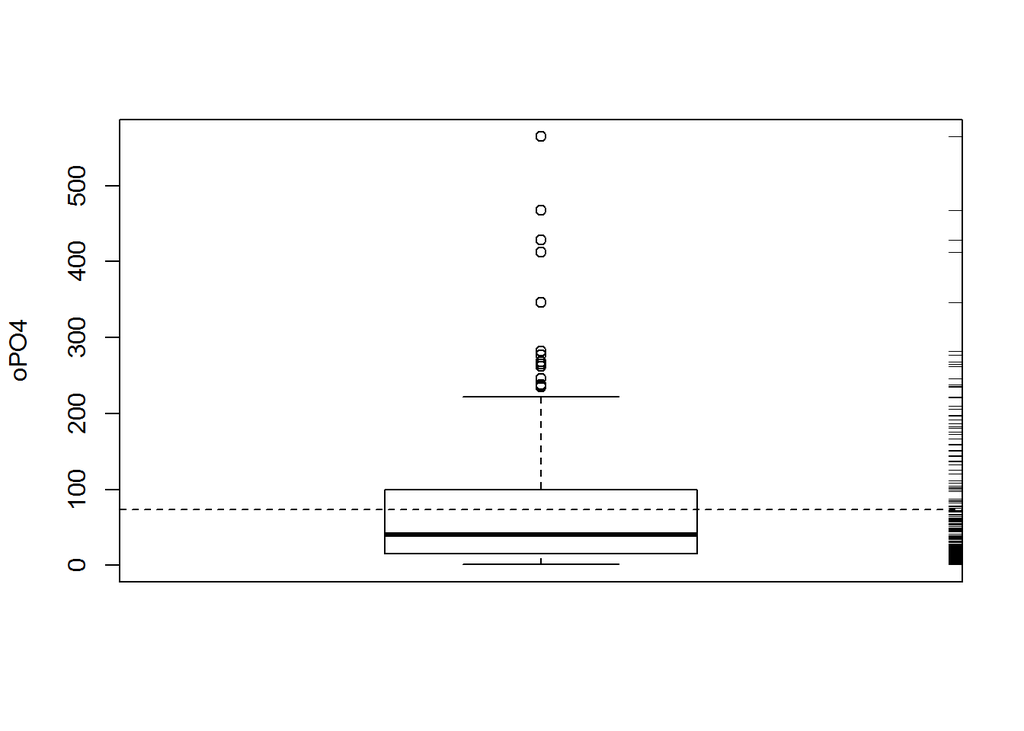

```r
boxplot(algae$oPO4,ylab='oPO4')
rug(algae$oPO4,side=4)
abline(h=mean(algae$oPO4,na.rm=T),lty=2)
```

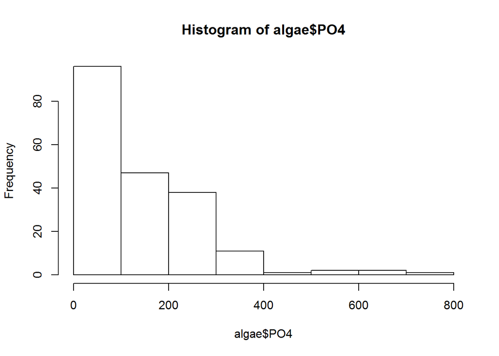

```r
hist(algae$PO4)
```

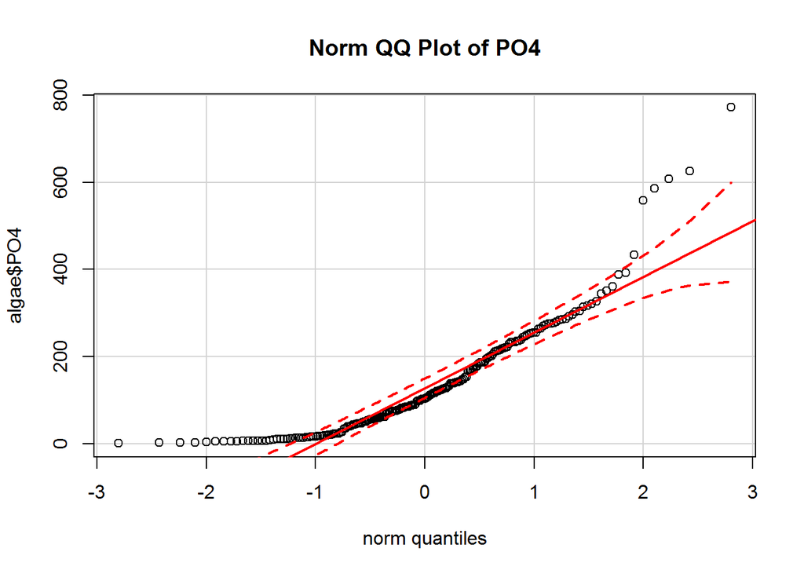

```r
qqPlot(algae$PO4,main='Norm QQ Plot of PO4')
```

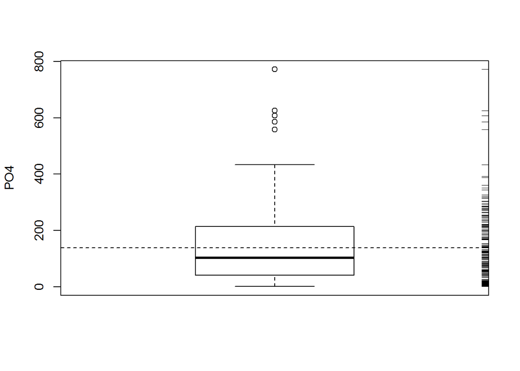

```r
boxplot(algae$PO4,ylab='PO4')
rug(algae$PO4,side=4)
abline(h=mean(algae$PO4,na.rm=T),lty=2)
```

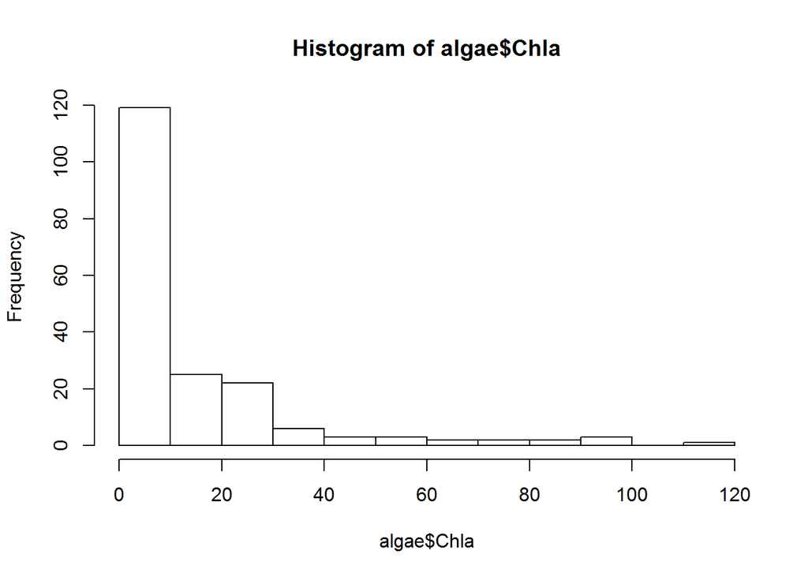

```r
hist(algae$Chla)
```

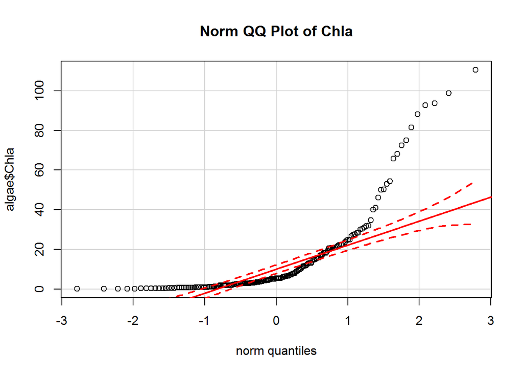

```r
qqPlot(algae$Chla,main='Norm QQ Plot of Chla')
```

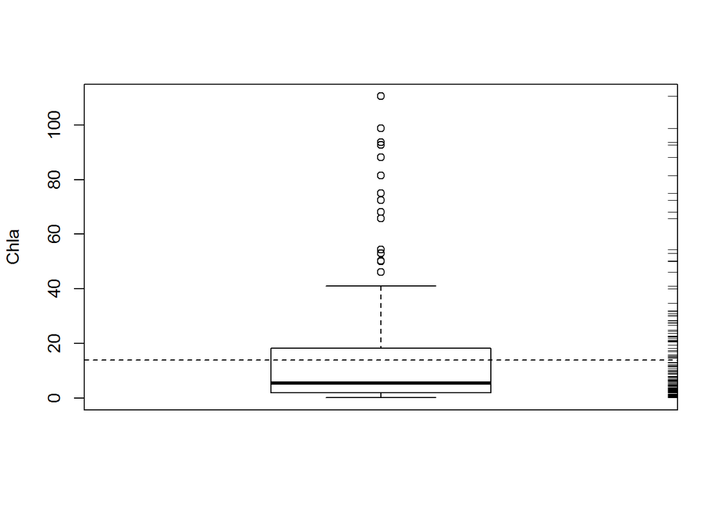

```r
boxplot(algae$Chla,ylab='Chla')
rug(algae$Chla,side=4)
abline(h=mean(algae$Chla,na.rm=T),lty=2)
```

### 4.2 条件盒图

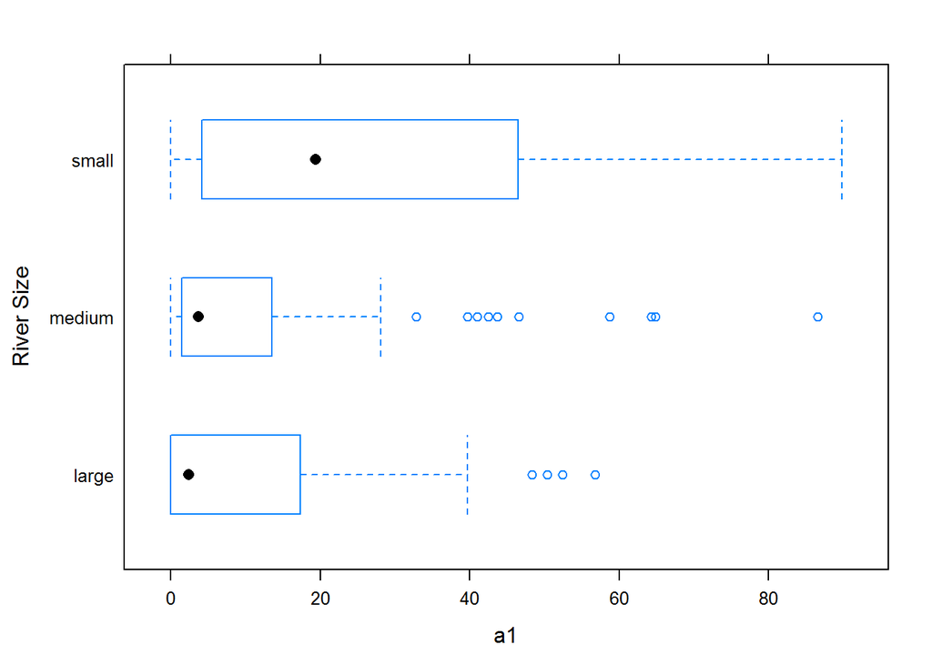

```r
bwplot(size~a1,data=algae,ylab='River Size',xlab='a1')
```

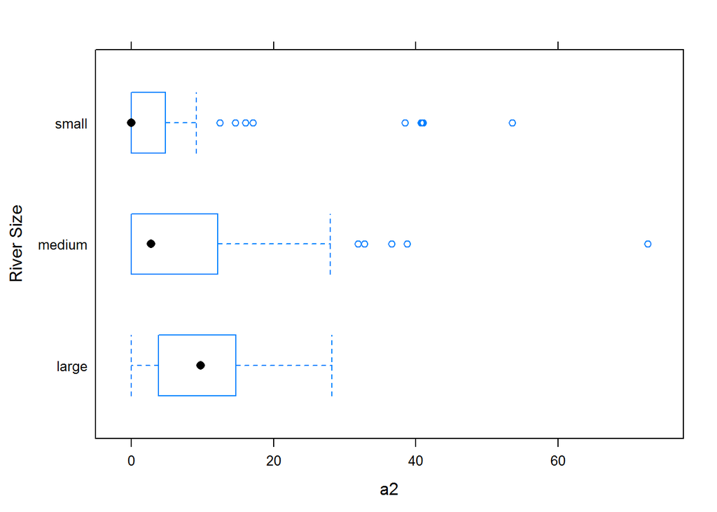

```r
bwplot(size~a2,data=algae,ylab='River Size',xlab='a2')
```

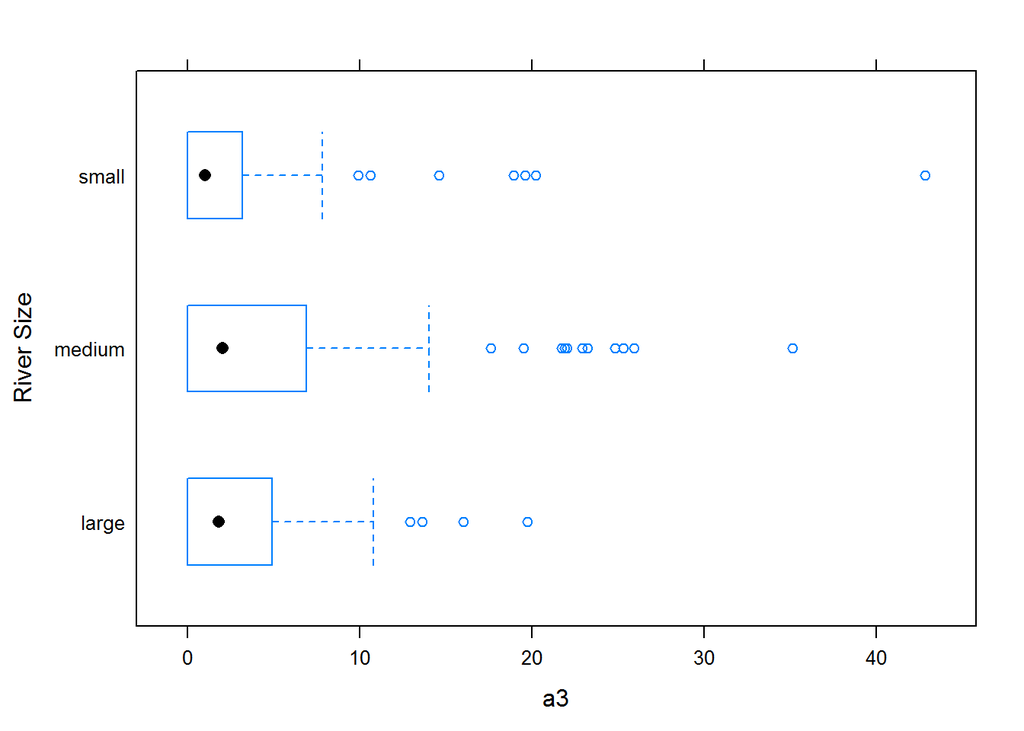

```r
bwplot(size~a3,data=algae,ylab='River Size',xlab='a3')
```

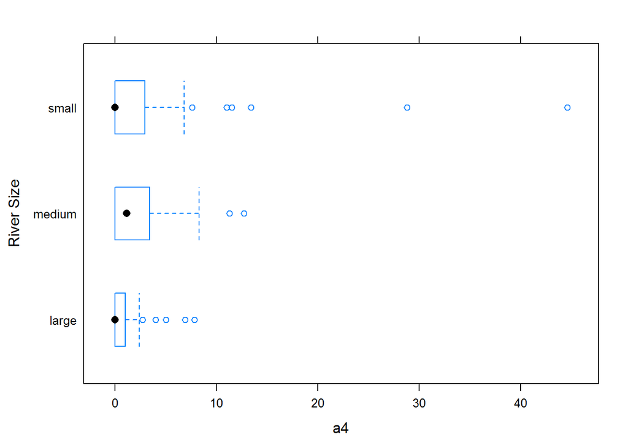

```r
bwplot(size~a4,data=algae,ylab='River Size',xlab='a4')
```

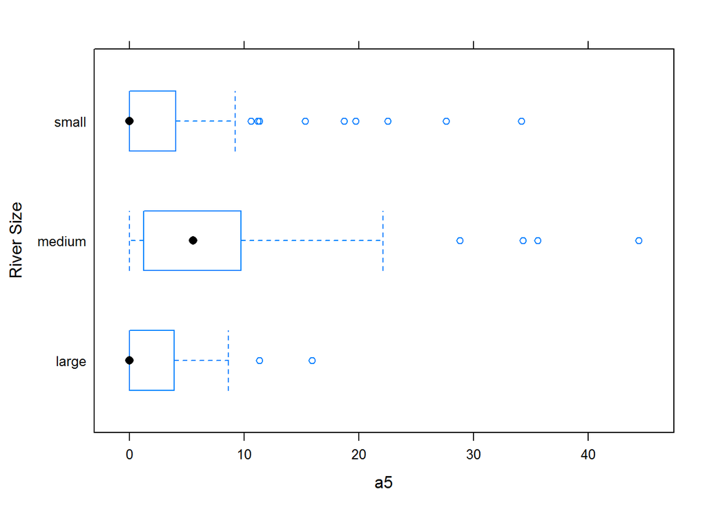

```r
bwplot(size~a5,data=algae,ylab='River Size',xlab='a5')
```

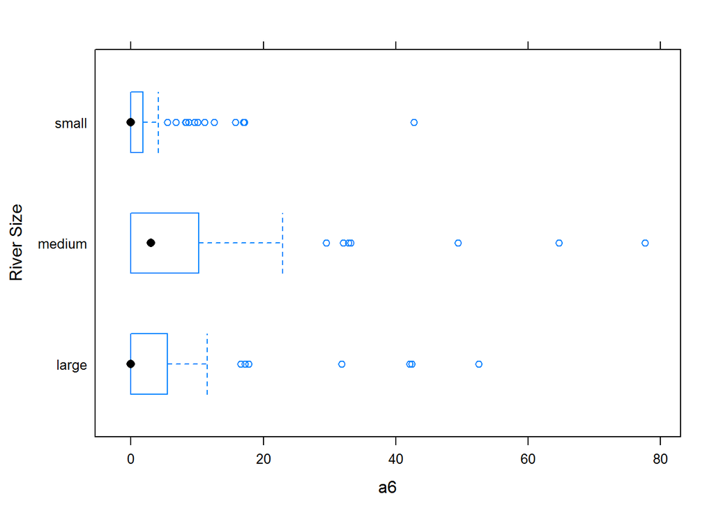

```r
bwplot(size~a6,data=algae,ylab='River Size',xlab='a6')
```

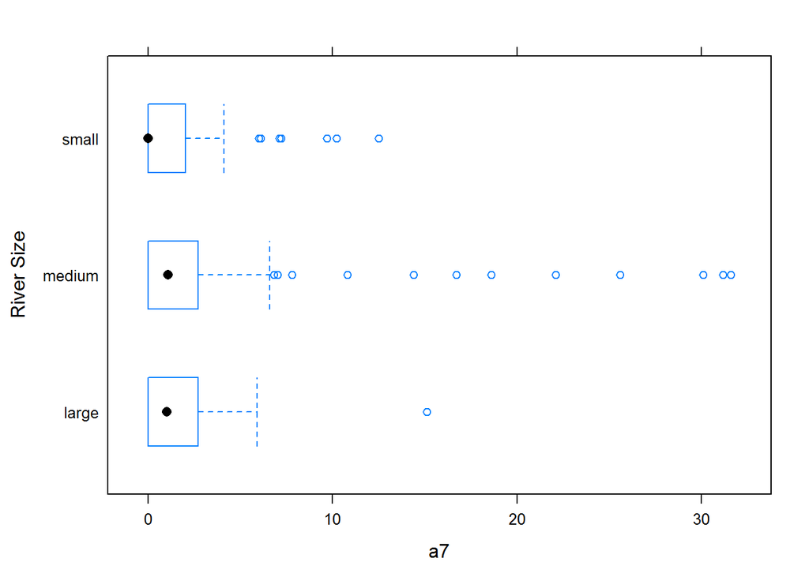

```r
bwplot(size~a7,data=algae,ylab='River Size',xlab='a7')
```